# Obj2.2: Nonparametric Model

Leonardo Leal Filho

2022-05-29

```r
library(tidyverse)
library(GGally)
library(class)
```

```r
setwd(dirname(rstudioapi::getSourceEditorContext()$path))
```

```r
LifeExpecFilePath = "../Datasets/LifeExpectancyData.csv"
df <- read.csv(LifeExpecFilePath)
```

## Checking the data

```r
dim(df)
```

```
## [1] 2938   22
```

```r
summary(df)
```

```
##    Country               Year         Status          Life.expectancy
##  Length:2938        Min.   :2000   Length:2938        Min.   :36.30
##  Class :character   1st Qu.:2004   Class :character   1st Qu.:63.10
##  Mode  :character   Median :2008   Mode  :character   Median :72.10
##                     Mean   :2008                      Mean   :69.22
##                     3rd Qu.:2012                      3rd Qu.:75.70
##                     Max.   :2015                      Max.   :89.00
##                                                       NA's   :10
##  Adult.Mortality infant.deaths       Alcohol        percentage.expenditure
##  Min.   :  1.0   Min.   :   0.0   Min.   : 0.0100   Min.   :    0.000
##  1st Qu.: 74.0   1st Qu.:   0.0   1st Qu.: 0.8775   1st Qu.:    4.685
##  Median :144.0   Median :   3.0   Median : 3.7550   Median :   64.913
##  Mean   :164.8   Mean   :  30.3   Mean   : 4.6029   Mean   :  738.251
##  3rd Qu.:228.0   3rd Qu.:  22.0   3rd Qu.: 7.7025   3rd Qu.:  441.534
##  Max.   :723.0   Max.   :1800.0   Max.   :17.8700   Max.   :19479.912
##  NA's   :10                       NA's   :194
##   Hepatitis.B       Measles              BMI        under.five.deaths
##  Min.   : 1.00   Min.   :     0.0   Min.   : 1.00   Min.   :   0.00
##  1st Qu.:77.00   1st Qu.:     0.0   1st Qu.:19.30   1st Qu.:   0.00
##  Median :92.00   Median :    17.0   Median :43.50   Median :   4.00
##  Mean   :80.94   Mean   :  2419.6   Mean   :38.32   Mean   :  42.04
##  3rd Qu.:97.00   3rd Qu.:   360.2   3rd Qu.:56.20   3rd Qu.:  28.00
##  Max.   :99.00   Max.   :212183.0   Max.   :87.30   Max.   :2500.00
##  NA's   :553                        NA's   :34
##      Polio       Total.expenditure   Diphtheria       HIV.AIDS
##  Min.   : 3.00   Min.   : 0.370    Min.   : 2.00   Min.   : 0.100
##  1st Qu.:78.00   1st Qu.: 4.260    1st Qu.:78.00   1st Qu.: 0.100
##  Median :93.00   Median : 5.755    Median :93.00   Median : 0.100
##  Mean   :82.55   Mean   : 5.938    Mean   :82.32   Mean   : 1.742
##  3rd Qu.:97.00   3rd Qu.: 7.492    3rd Qu.:97.00   3rd Qu.: 0.800
##  Max.   :99.00   Max.   :17.600    Max.   :99.00   Max.   :50.600
##  NA's   :19      NA's   :226       NA's   :19
##       GDP              Population        thinness..1.19.years
##  Min.   :     1.68   Min.   :3.400e+01   Min.   : 0.10
##  1st Qu.:   463.94   1st Qu.:1.958e+05   1st Qu.: 1.60
##  Median :  1766.95   Median :1.387e+06   Median : 3.30
##  Mean   :  7483.16   Mean   :1.275e+07   Mean   : 4.84
##  3rd Qu.:  5910.81   3rd Qu.:7.420e+06   3rd Qu.: 7.20
##  Max.   :119172.74   Max.   :1.294e+09   Max.   :27.70
##  NA's   :448         NA's   :652         NA's   :34
##  thinness.5.9.years Income.composition.of.resources   Schooling
##  Min.   : 0.10      Min.   :0.0000                  Min.   : 0.00
##  1st Qu.: 1.50      1st Qu.:0.4930                  1st Qu.:10.10
##  Median : 3.30      Median :0.6770                  Median :12.30
##  Mean   : 4.87      Mean   :0.6276                  Mean   :11.99
##  3rd Qu.: 7.20      3rd Qu.:0.7790                  3rd Qu.:14.30
##  Max.   :28.60      Max.   :0.9480                  Max.   :20.70
##  NA's   :34         NA's   :167                     NA's   :163
```

## Checking the features with NA values and how many NA values each has

```r
# Creating an empty vector to collect the features that have NA values
na.feat <- c()

# Looping through the dataset to collect the features with NA values
for (i in names(df)) {
  if (sum(is.na(df[,i])) > 0) {
    na.feat <- c(na.feat, i)
  }
}

# Making an empty dataframe to store the names of the features with NA values and how many NA values they have
na.count <- data.frame(Features = na.feat, Count = numeric(length(na.feat)))

# Looping through the dataset to collect the count of NA values those features have
for (i in 1:length(na.feat)) {
  na.count[i, 2] <- sum(is.na(df[, na.feat[i]]))
}

# Checking the na.count dataframe
na.count
```

```
##                           Features Count
## 1                  Life.expectancy    10
## 2                  Adult.Mortality    10
## 3                          Alcohol   194
## 4                      Hepatitis.B   553
## 5                              BMI    34
## 6                            Polio    19
## 7                Total.expenditure   226
## 8                       Diphtheria    19
## 9                              GDP   448
## 10                      Population   652
## 11            thinness..1.19.years    34
## 12              thinness.5.9.years    34
## 13 Income.composition.of.resources   167
## 14                       Schooling   163
```

## Removing some rows with NA values

```r
# Finding the rows of "thinnes..1.19.years" that contains NA values
n1 <- which(is.na(df$thinness..1.19.years))
# Removing the rows
df <- df[-n1,]
```

```r
# Creating an empty vector to collect the features that have NA values
na.feat <- c()

# Looping through the dataset to collect the features with NA values
for (i in names(df)) {
  if (sum(is.na(df[,i])) > 0) {
    na.feat <- c(na.feat, i)
  }
}

# Making an empty dataframe to store the names of the features with NA values and how many NA values they have
na.count <- data.frame(Features = na.feat, Count = numeric(length(na.feat)))

# Looping through the dataset to collect the count of NA values those features have
for (i in 1:length(na.feat)) {
  na.count[i, 2] <- sum(is.na(df[, na.feat[i]]))
}

# Checking the na.count dataframe
na.count
```

```
##                           Features Count
## 1                  Life.expectancy     8
## 2                  Adult.Mortality     8
## 3                          Alcohol   177
## 4                      Hepatitis.B   533
## 5                            Polio     8
## 6                Total.expenditure   212
## 7                       Diphtheria     8
## 8                              GDP   438
## 9                       Population   650
## 10 Income.composition.of.resources   165
## 11                       Schooling   162
```

```r
# Finding the rows of "Polio" that contains NA values
n1 <- which(is.na(df$Polio))
# Removing the rows
df <- df[-n1,]
```

```r
# Creating an empty vector to collect the features that have NA values
na.feat <- c()

# Looping through the dataset to collect the features with NA values
for (i in names(df)) {
  if (sum(is.na(df[,i])) > 0) {
    na.feat <- c(na.feat, i)
  }
}

# Making an empty dataframe to store the names of the features with NA values and how many NA values they have
na.count <- data.frame(Features = na.feat, Count = numeric(length(na.feat)))

# Looping through the dataset to collect the count of NA values those features have
for (i in 1:length(na.feat)) {
  na.count[i, 2] <- sum(is.na(df[, na.feat[i]]))
}

# Checking the na.count dataframe
na.count
```

```
##                          Features Count
## 1                 Life.expectancy     8
## 2                 Adult.Mortality     8
## 3                         Alcohol   176
## 4                     Hepatitis.B   525
## 5               Total.expenditure   212
## 6                             GDP   438
## 7                      Population   650
## 8 Income.composition.of.resources   165
## 9                       Schooling   162
```

lastly I will remove the rows that contains missing values for the “Adult.Mortality” feature.

```r
# Finding the rows of "Adult.Mortality" that contains NA values
n1 <- which(is.na(df$Adult.Mortality))
# Removing the rows
df <- df[-n1,]
```

```r
# Creating an empty vector to collect the features that have NA values
na.feat <- c()

# Looping through the dataset to collect the features with NA values
for (i in names(df)) {
  if (sum(is.na(df[,i])) > 0) {
    na.feat <- c(na.feat, i)
  }
}

# Making an empty dataframe to store the names of the features with NA values and how many NA values they have
na.count <- data.frame(Features = na.feat, Count = numeric(length(na.feat)))

# Looping through the dataset to collect the count of NA values those features have
for (i in 1:length(na.feat)) {
  na.count[i, 2] <- sum(is.na(df[, na.feat[i]]))
}

# Checking the na.count dataframe
na.count
```

```
##                          Features Count
## 1                         Alcohol   175
## 2                     Hepatitis.B   525
## 3               Total.expenditure   212
## 4                             GDP   435
## 5                      Population   644
## 6 Income.composition.of.resources   160
## 7                       Schooling   160
```

```r
dim(df)
```

```
## [1] 2888   22
```

```r
data.frame(cor(df[,c("Life.expectancy", na.count$Features)]))
```

```
##                                 Life.expectancy Alcohol Hepatitis.B
## Life.expectancy                               1      NA          NA
## Alcohol                                      NA       1          NA
## Hepatitis.B                                  NA      NA           1
## Total.expenditure                            NA      NA          NA
## GDP                                          NA      NA          NA
## Population                                   NA      NA          NA
## Income.composition.of.resources              NA      NA          NA
## Schooling                                    NA      NA          NA
##                                 Total.expenditure GDP Population
## Life.expectancy                                NA  NA         NA
## Alcohol                                        NA  NA         NA
## Hepatitis.B                                    NA  NA         NA
## Total.expenditure                               1  NA         NA
## GDP                                            NA   1         NA
## Population                                     NA  NA          1
## Income.composition.of.resources                NA  NA         NA
## Schooling                                      NA  NA         NA
##                                 Income.composition.of.resources Schooling
## Life.expectancy                                              NA        NA
## Alcohol                                                      NA        NA
## Hepatitis.B                                                  NA        NA
## Total.expenditure                                            NA        NA
## GDP                                                          NA        NA
## Population                                                   NA        NA
## Income.composition.of.resources                               1        NA
## Schooling                                                    NA         1
```

### I will now remove the features that have missing data left.

### I will also remove the “Country” feature because since 50 rows were removed from the dataset, some countries may not be fully represented, if at all. This means making prediction based on countries may not yield any results due to the country not being in the training of the model.

### The “Year” feature will also be removed because I am not planning to build a time series model. Using the “Year” feature would mean that any prediction would be for a Year that is not within the actual dataset, which means the model would not have been trained on that value so it would extrapolate.

```r
# Removing the features that have 160 or more NA values plus the "Country" and "Year" features.
df2 <- df %>% select(!c(na.count$Features, "Country", "Year"))
```

```r
dim(df2)
```

```
## [1] 2888   13
```

```r
str(df2)
```

```
## 'data.frame':    2888 obs. of  13 variables:
##  $ Status                : chr  "Developing" "Developing" "Developing" "Developing" ...
##  $ Life.expectancy       : num  65 59.9 59.9 59.5 59.2 58.8 58.6 58.1 57.5 57.3 ...
##  $ Adult.Mortality       : int  263 271 268 272 275 279 281 287 295 295 ...
##  $ infant.deaths         : int  62 64 66 69 71 74 77 80 82 84 ...
##  $ percentage.expenditure: num  71.3 73.5 73.2 78.2 7.1 ...
##  $ Measles               : int  1154 492 430 2787 3013 1989 2861 1599 1141 1990 ...
##  $ BMI                   : num  19.1 18.6 18.1 17.6 17.2 16.7 16.2 15.7 15.2 14.7 ...
##  $ under.five.deaths     : int  83 86 89 93 97 102 106 110 113 116 ...
##  $ Polio                 : int  6 58 62 67 68 66 63 64 63 58 ...
##  $ Diphtheria            : int  65 62 64 67 68 66 63 64 63 58 ...
##  $ HIV.AIDS              : num  0.1 0.1 0.1 0.1 0.1 0.1 0.1 0.1 0.1 0.1 ...
##  $ thinness..1.19.years  : num  17.2 17.5 17.7 17.9 18.2 18.4 18.6 18.8 19 19.2 ...
##  $ thinness.5.9.years    : num  17.3 17.5 17.7 18 18.2 18.4 18.7 18.9 19.1 19.3 ...
```

### The only non numerical feature left is the “Status” feature. Let me check how many factors are in that feature and what are they.

```r
# Transforming the "Status" feature from a character to a factor feature
df2$Status <- as.factor(df2$Status)

# Checking how the "Status" feature is now
summary(df2$Status)
```

```
##  Developed Developing
##        512       2376
```

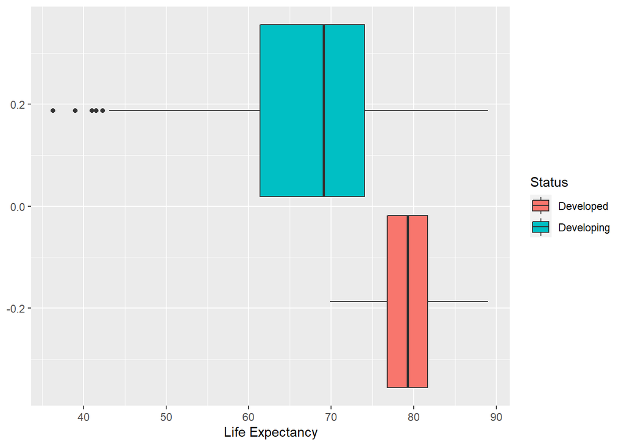

```r
# Status feature boxplot
df2 %>% ggplot(aes(x = Life.expectancy, fill = Status)) + geom_boxplot() + xlab("Life Expectancy")
```

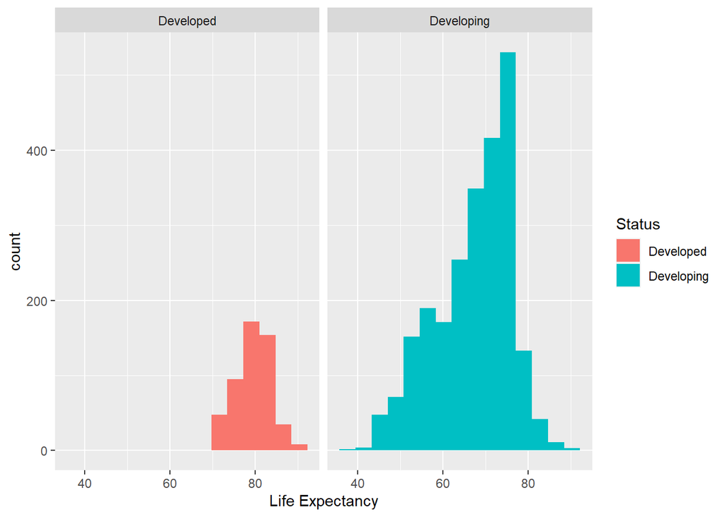

```r
# Status feature histogram
df2 %>% ggplot(aes(x = Life.expectancy, fill = Status)) + geom_histogram(bins = 15) + facet_wrap(~Status) + xlab("Life Expectancy")
```

### The summary shows there are two factors in the “Status” feature: Developed and Developing. The histograms do not show any strong evidence against normality. With that in mind, I will perform a Welch’s t-test to see if there is a difference in the mean Life Expectancy between the Developed status vs. the Developing status.

```r
Developed <- df[df$Status == "Developed",]$Life.expectancy
Developing <- df[df$Status == "Developing",]$Life.expectancy
t.test(Developed, Developing)
```

```
##
##  Welch Two Sample t-test
##
## data:  Developed and Developing
## t = 47.24, df = 1816.3, p-value < 2.2e-16
## alternative hypothesis: true difference in means is not equal to 0
## 95 percent confidence interval:
##  11.47372 12.46770
## sample estimates:
## mean of x mean of y
##  79.19785  67.22715
```

### The t-test results indicate that there is overwhelming evidence that the mean life expectancy from developed countries is not the same as the mean life expectancy of developing country. The results also shows, with 95% confidence, that the mean life expectance from developed countries is approximately between 11.47 to 12.47 years longer than the mean life expectance of the developing countries. These results are great to keep in mind when picking the features to implement in the model.

### In order to use the Status feature, I will create a dummy feature called “Developed” to replace it with a numeric feature. The values in the “Developed” feature will be 1 if the “Status” is “Developed” or 0 if the “Status” is Developing.

```r
# Creating a "Developed" feature
df2$Developed <- ifelse(df$Status == "Developed", 1, 0)
# Dropping the "Status" feature
df2 <- df2 %>% select(!Status)
```

### A non parametric model does not require a linear relationship between response and explanatory vairables. With that being said, explanatory variables that have a strong correlation to the response variable may be more useful to make predictions on new data.

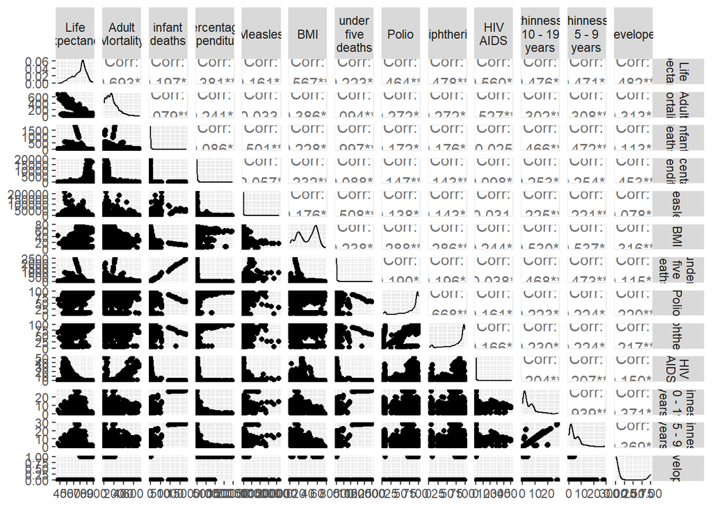

```r
# library with ggpairs
library(GGally)

# Creating a new dataframe just to be able to change the features' titles
df3 <- df2

# Changing the features' titles just so that they can best fit the ggpairs graph
names(df3) <- c("Life expectancy",  "Adult Mortality", "infant deaths",
                "percentage expenditure", "Measles", "BMI", "under five deaths",
                "Polio", "Diphtheria", "HIV AIDS", "thinness 10 - 19 years",
                "thinness 5 - 9 years", "Developed")

# Creating the ggpairs graph
ggpairs(df3, labeller = label_wrap_gen(8))
```

```r
# Creating a correlation dataframe
c <- data.frame(cor(df2))
# Checking the correlation dataframe where the absolute correlation from Life.expectancy is above 0.4
c[abs(c$Life.expectancy) > 0.4,] %>% select(Life.expectancy)
```

```
##                      Life.expectancy
## Life.expectancy            1.0000000
## Adult.Mortality           -0.6931889
## BMI                        0.5670551
## Polio                      0.4641662
## Diphtheria                 0.4781941
## HIV.AIDS                  -0.5603818
## thinness..1.19.years      -0.4763420
## thinness.5.9.years        -0.4707437
## Developed                  0.4815494
```

```r
# Setting a seed to make it replicable
set.seed(1)

# Making an 80-20 train-test split
# Randomly selecting the indexes for the training set
train.index <- sample(dim(df2)[1], dim(df2)[1] * 0.80)

# Creating the training set using the train.index
train <- df2[train.index,]

# Creating the testing set
test <- df2[-train.index,]
```

```r
# library with tree function for the regression tree model
library(tree)
# Regression Tree Model
tree.model <- tree(Life.expectancy ~ ., data = train)
summary(tree.model)
```

```
##
## Regression tree:
## tree(formula = Life.expectancy ~ ., data = train)
## Variables actually used in tree construction:
## [1] "HIV.AIDS"             "Adult.Mortality"      "thinness.5.9.years"
## [4] "thinness..1.19.years" "under.five.deaths"
## Number of terminal nodes:  9
## Residual mean deviance:  15.91 = 36600 / 2301
## Distribution of residuals:
##      Min.   1st Qu.    Median      Mean   3rd Qu.      Max.
## -18.11000  -1.92000   0.03182   0.00000   2.23200  16.33000
```

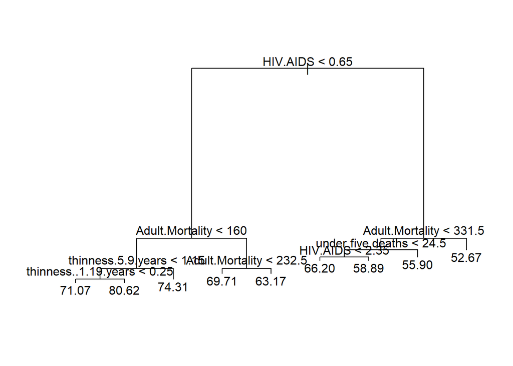

```r
# Plotting the tree model and its nodes
plot(tree.model)
text(tree.model)
```

```r
# library with trainControl, train, RMSE, and MAE
library(caret)
# Building a dataset with only the predictors from the test dataset
test.x <- test %>% select(-Life.expectancy)
# Making the prediction using the regression tree model
tree.pred <- predict(tree.model, test.x)

# Checking the RMSE and MAE from the predicted model
rmse <- RMSE(tree.pred, test$Life.expectancy)
mae <- MAE(tree.pred, test$Life.expectancy)
ase <- RMSE(tree.pred, test$Life.expectancy)^2
tree.results <- data.frame(RMSE = rmse, MAE = mae, ASE = ase)
tree.results
```

```
##       RMSE      MAE      ASE
## 1 3.853341 2.840269 14.84824
```

```r
# Setting seed to make model replicable due to the cross validation
set.seed(1)

# Creating a control variable to implement a 5 fold cross validation
fitControl <- trainControl(method = "cv", number = 5)

# Creating a knn model that will choose between 1 to 15 values for the "k" neighbors from which to take the mean.
knn.model <- train(Life.expectancy ~ Developed + Adult.Mortality + BMI + HIV.AIDS + thinness..1.19.years + thinness.5.9.years,
                    method = "knn", tuneGrid = expand.grid(k = 1:15), data = train, trControl = fitControl)
# Checking the model
knn.model
```

```
## k-Nearest Neighbors
##
## 2310 samples
##    6 predictor
##
## No pre-processing
## Resampling: Cross-Validated (5 fold)
## Summary of sample sizes: 1848, 1849, 1848, 1848, 1847
## Resampling results across tuning parameters:
##
##   k   RMSE      Rsquared   MAE
##    1  2.926589  0.9079577  1.792128
##    2  2.795234  0.9146842  1.792653
##    3  2.836619  0.9117669  1.833551
##    4  2.912031  0.9068157  1.879550
##    5  2.910040  0.9068234  1.914336
##    6  2.931591  0.9054413  1.943576
##    7  2.943802  0.9050372  1.956078
##    8  2.997388  0.9017863  1.983148
##    9  2.996092  0.9018471  1.995346
##   10  2.995059  0.9019707  1.999633
##   11  2.995857  0.9018594  2.013146
##   12  3.008507  0.9010343  2.027285
##   13  3.018936  0.9002746  2.031140
##   14  3.030091  0.8994181  2.049556
##   15  3.064968  0.8970868  2.073032
##
## RMSE was used to select the optimal model using the smallest value.
## The final value used for the model was k = 2.
```

```r
# Creating a test.x1 data set with only the variable used in the creation of the model, without the response variable.
test.x <- test %>% select(!Life.expectancy)
test.x <- test %>% select(Developed, Adult.Mortality, BMI, HIV.AIDS, thinness..1.19.years, thinness.5.9.years)

# Making predictions with the testing data
knn.pred <- predict(knn.model, test.x)

RMSE(knn.pred, test$Life.expectancy)
```

```
## [1] 2.330442
```

```r
MAE(knn.pred, test$Life.expectancy)
```

```
## [1] 1.56064
```

```r
# Retrieving the RMSE, Rsquared, MAE for each of the k values
knn.Results <- knn.model$results %>% select(k, RMSE, Rsquared, MAE)

# Creating the ASE by squaring the RMSE
knn.Results$ASE <- knn.Results$RMSE^2

# Checking the results table
knn.Results
```

```
##     k     RMSE  Rsquared      MAE      ASE
## 1   1 2.926589 0.9079577 1.792128 8.564926
## 2   2 2.795234 0.9146842 1.792653 7.813333
## 3   3 2.836619 0.9117669 1.833551 8.046408
## 4   4 2.912031 0.9068157 1.879550 8.479923
## 5   5 2.910040 0.9068234 1.914336 8.468332
## 6   6 2.931591 0.9054413 1.943576 8.594225
## 7   7 2.943802 0.9050372 1.956078 8.665967
## 8   8 2.997388 0.9017863 1.983148 8.984335
## 9   9 2.996092 0.9018471 1.995346 8.976570
## 10 10 2.995059 0.9019707 1.999633 8.970378
## 11 11 2.995857 0.9018594 2.013146 8.975158
## 12 12 3.008507 0.9010343 2.027285 9.051115
## 13 13 3.018936 0.9002746 2.031140 9.113973
## 14 14 3.030091 0.8994181 2.049556 9.181449
## 15 15 3.064968 0.8970868 2.073032 9.394031
```

```r
# Creating a dataframe with the Actual and Predicted values for the testing set
res <- data.frame(Actual = test$Life.expectancy, Predicted = knn.pred)

# Calculating the residuals by subtracting the Predicted from the Actual
res$Residuals <- res$Actual - res$Predicted

# Squaring the Residual values
res$Squared.Residuals <- res$Residuals^2

# Taking the Average of the Squared Residuals
ASE <- mean(res$Squared.Residuals)

# Checking the ASE
ASE
```

```
## [1] 5.430962
```